# Time dependent AUC with survival data _ correct1

Hwang Seong-Yun

2022 4 11

# Loading packages

```r
library(survival)
library(timeROC)
library(timereg)
```

```r
library(ggplot2)
library(reshape)
library(plyr)
library(tidyverse)
library(coxed)
library(gridExtra)
```

# Generating simulation data from Cox regression

## Background

- reference 1 : https://doi.org/10.5351/KJAS.2018.31.6.761
- reference 2 : https://doi.org/10.1017/psrm.2018.19
- $h(t|x)=h_{0}(t)exp(f(x))$
- $H(t|x)=\int_{0}^{t} h(s|x)ds= \int_{0}^{t} h_{0}(s)exp(f(x))ds=H_{0}(t)exp(f(x))$
- $h(t|x)=\frac {f(t|x)}{S(t|x)}= -\frac {d}{dt} log[S(t|x)]$
- $log[S(t|x)]= -\int_{0}^{t} h(s|x)ds= -H(t|x)= -H_{0}(t)exp(f(x))$
- $S(t|x)=exp[-H_{0}(t)exp(f(x))]$
- In general,…
- $F(t|x)=1-exp[-H_{0}(t) exp(f(x))]$
- -> $F^{-1}(t|x)=H_{0}^{-1}[-log(1-t) exp(-f(x))]$
- By Inverse Transform Sampling, suppose that $U_{1}, U_{2} \overset{i.i.d}{\sim}\ U(0,1)$, then we can generate real survival time $Y$ from Cox Proportional Hazard Model using this equation.
- $Y=H_{Y0}^{-1}[-log(U_{1})exp(-f(x))]$
- And by assuming non-informative censoring, we can generate censoring time $C$ like this equation. (Set $Y$ and $C$ are independent each other.)
- $C=H_{C0}^{-1}[-log(U_{2})]$
- And set censoring indicator $\delta=I(Y \leq C)$ and observed survival time $T=min(Y,C)$
- $H_{Y0}(t|x)$ : Basis cumulative hazard function of real survival time $Y$
- $H_{C0}(t)$ : Basis cumulative hazard function of censoring time $C$
- When parametric basis distribution of real survival time $Y$ and censoring time $C$ are Exponential distribution and independent each other, then ~
- $f_{0}(t)=\lambda e^{-\lambda t}, t>0$ -> $S_{0}(t)=e^{-\lambda t}$ -> $h_{0}(t)=\lambda$
- $\therefore Y=-\frac{1}{\lambda} log(U_{1}) exp(-f(x))$, $C=-\frac{1}{\lambda} log(U_{2})$

# Generating simulation data

## Assume linear relationship

```r
# Assume parametric basis distribution is Exponential distribution...
lambda1 <- 0.1 # parameter for generate Y
lambda2 <- 0.05 # parameter for generate C
beta1 <- 3 # true coefficients
Y <- c() # real survival time
C <- c() # censoring time
t <- c() # observed survival time
censor <- c() # censoring indicator
X <- c() # explanatory variable
U1 <- c() # random variable from U(0,1) for generate Y
U2 <- c() # random variable from U(0,1) for generate C
X2 <- c() # X^2

for (i in 1:10000) {
  U1[i] <- runif(1)
  U2[i] <- runif(1)
  # X[i] <- runif(1,min=0,max=10)
  X[i] <- rnorm(1,mean=0,sd=1)
  X2[i] <- X[i]^2
  Y[i] <- -(1/lambda1)*log(U1[i])*exp(-beta1*X[i])
  C[i] <- -(1/lambda2)*log(U2[i])
  t[i] <- min(Y[i],C[i])
  censor[i] <- ifelse(Y[i]<=C[i],1,0)
}

mean(1-censor) # censoring rate
```

```
## [1] 0.4236
```

```r
dt1 <- data.frame(X=X, X2=X2, Y=Y, C=C, time=t, censor=censor)
head(dt1,20)
```

```
##             X         X2            Y         C        time censor
## 1  -1.3990220 1.95726269 9.833817e+02 10.173603 10.17360336      0
## 2  -0.8613717 0.74196120 4.300752e+01 13.812879 13.81287932      0
## 3  -1.7396081 3.02623622 4.860472e+02 17.509053 17.50905275      0
## 4  -0.7734918 0.59828963 1.047563e+01  5.666435  5.66643510      0
## 5   0.3297663 0.10874583 7.072775e-01 11.753664  0.70727752      1
## 6   0.6172904 0.38104739 2.657134e+00 22.354642  2.65713438      1
## 7  -1.0070440 1.01413760 7.254635e+01  3.955017  3.95501740      0
## 8   0.5649730 0.31919449 1.304947e+00 42.265088  1.30494653      1
## 9  -0.1546169 0.02390638 6.039625e+00 40.009526  6.03962511      1
## 10  1.4077092 1.98164531 2.406014e-01 33.185393  0.24060141      1
## 11 -0.4075329 0.16608307 8.300099e+01  2.197981  2.19798068      0
## 12  1.2497961 1.56199034 1.725932e-01 27.777633  0.17259323      1
## 13  0.1990899 0.03963678 2.488609e+01  7.481300  7.48129984      0
## 14 -2.6904475 7.23850795 1.046981e+04 45.846691 45.84669109      0
## 15 -0.3506848 0.12297983 2.623534e+02 33.029293 33.02929284      0
## 16  1.0441624 1.09027507 1.911650e-01 24.160674  0.19116501      1
## 17  0.3249124 0.10556804 1.606095e+01  6.552420  6.55242041      0
## 18 -0.3611901 0.13045829 2.000338e+01  1.126144  1.12614376      0
## 19  0.8199468 0.67231271 5.835131e-02 76.223461  0.05835131      1
## 20 -0.7844781 0.61540596 1.117571e+02  5.378623  5.37862329      0
```

```r
# dt1[c(order(dt1$time)),]$censor
```

### True model

- $h(t|x)=h _{0} (t)exp[f(x)]$
- $f(x)=\beta_{1} x$
- True coefficients : $\beta_{1}=3$

### Set linear model

- $h(t|x)=h _{0} (t)exp[f(x)]$
- $f(x)=\beta_{1}x$

```r
cox.lin.dt1 <- coxph(Surv(time,censor) ~ X, data=dt1)
summary(cox.lin.dt1)
```

```
## Call:
## coxph(formula = Surv(time, censor) ~ X, data = dt1)
##
##   n= 10000, number of events= 5764
##
##       coef exp(coef) se(coef)     z Pr(>|z|)
## X  3.02200  20.53241  0.03094 97.66   <2e-16 ***
## ---
## Signif. codes:  0 '***' 0.001 '**' 0.01 '*' 0.05 '.' 0.1 ' ' 1
##
##   exp(coef) exp(-coef) lower .95 upper .95
## X     20.53     0.0487     19.32     21.82
##
## Concordance= 0.896  (se = 0.002 )
## Likelihood ratio test= 14660  on 1 df,   p=<2e-16
## Wald test            = 9537  on 1 df,   p=<2e-16
## Score (logrank) test = 10583  on 1 df,   p=<2e-16
```

```r
risk.lin.dt1 <- predict(object=cox.lin.dt1, newdata=dt1, type="risk") # risk score
dt1$risk.lin.dt1 <- risk.lin.dt1
ROC.risk.lin.dt1 <- timeROC(T=dt1$time,
                         delta=dt1$censor,marker=dt1$risk.lin.dt1,
                         cause=1,weighting="marginal",
                         times=dt1$time)
ROC.risk.lin.dt1
```

```
## Time-dependent-Roc curve estimated using IPCW  (n=10000, without competing risks).
##                        Cases Survivors Censored AUC (%)
## t=5.80148567018888e-06     0      9999        1      NA
## t=0.54282653059693      2275      7499      226   95.25
## t=3.02965443438565      4026      5000      974   95.04
## t=10.2821685687901      5171      2500     2329   95.75
## t=146.316180774587      5764         0     4236      NA
##
## Method used for estimating IPCW:marginal
##
## Total computation time : 35.68  secs.
```

### Set quadratic model

- $h(t|x)=h _{0} (t)exp[f(x)]$
- $f(x)=\beta_{1}x+\beta_{2}x^2$

```r
cox.quad.dt1 <- coxph(Surv(time,censor) ~ X+X2, data=dt1)
summary(cox.quad.dt1)
```

```
## Call:
## coxph(formula = Surv(time, censor) ~ X + X2, data = dt1)
##
##   n= 10000, number of events= 5764
##
##         coef exp(coef)  se(coef)      z Pr(>|z|)
## X   3.025961 20.613797  0.040097 75.466   <2e-16 ***
## X2 -0.003307  0.996698  0.021278 -0.155    0.876
## ---
## Signif. codes:  0 '***' 0.001 '**' 0.01 '*' 0.05 '.' 0.1 ' ' 1
##
##    exp(coef) exp(-coef) lower .95 upper .95
## X    20.6138    0.04851    19.056    22.299
## X2    0.9967    1.00331     0.956     1.039
##
## Concordance= 0.896  (se = 0.002 )
## Likelihood ratio test= 14660  on 2 df,   p=<2e-16
## Wald test            = 9525  on 2 df,   p=<2e-16
## Score (logrank) test = 19647  on 2 df,   p=<2e-16
```

```r
risk.quad.dt1 <- predict(object=cox.quad.dt1, newdata=dt1, type="risk") # risk score
dt1$risk.quad.dt1 <- risk.quad.dt1
ROC.risk.quad.dt1 <- timeROC(T=dt1$time,
                         delta=dt1$censor,marker=dt1$risk.quad.dt1,
                         cause=1,weighting="marginal",
                         times=dt1$time)
ROC.risk.quad.dt1
```

```
## Time-dependent-Roc curve estimated using IPCW  (n=10000, without competing risks).
##                        Cases Survivors Censored AUC (%)
## t=5.80148567018888e-06     0      9999        1      NA
## t=0.54282653059693      2275      7499      226   95.25
## t=3.02965443438565      4026      5000      974   95.04
## t=10.2821685687901      5171      2500     2329   95.75
## t=146.316180774587      5764         0     4236      NA
##
## Method used for estimating IPCW:marginal
##
## Total computation time : 80.06  secs.
```

#### Make AUC data

```r
# uncensored
uncensored.density1 <- density(dt1$time[dt1$censor==1])
data1_1 <- data.frame(time=uncensored.density1[["x"]],
                    density=uncensored.density1[["y"]])
data1_1$density.adjusted <- (max(na.omit(ROC.risk.lin.dt1[["AUC"]]))-min(na.omit(ROC.risk.lin.dt1[["AUC"]])))*(uncensored.density1[["y"]]-min(uncensored.density1[["y"]]))/(max(uncensored.density1[["y"]])-min(uncensored.density1[["y"]]))+min(na.omit(ROC.risk.lin.dt1[["AUC"]]))

# censored
censored.density1 <- density(dt1$time[dt1$censor==0])
data1_2 <- data.frame(time=censored.density1[["x"]],
                    density=censored.density1[["y"]])
data1_2$density.adjusted <- (max(na.omit(ROC.risk.lin.dt1[["AUC"]]))-min(na.omit(ROC.risk.lin.dt1[["AUC"]])))*(censored.density1[["y"]]-min(censored.density1[["y"]]))/(max(censored.density1[["y"]])-min(censored.density1[["y"]]))+min(na.omit(ROC.risk.lin.dt1[["AUC"]]))

res1 <- data.frame(time=ROC.risk.lin.dt1[["times"]],
                    cox.lin.dt1=ROC.risk.lin.dt1[["AUC"]],
                    cox.quad.dt1=ROC.risk.quad.dt1[["AUC"]])
res1 <- melt(data = res1,
                   id.vars = "time",
                   measure.vars = c("cox.lin.dt1","cox.quad.dt1"))
```

#### Time dependent AUC plot with ggplot2 (cox.lin.dt1, cox.quad.dt1)

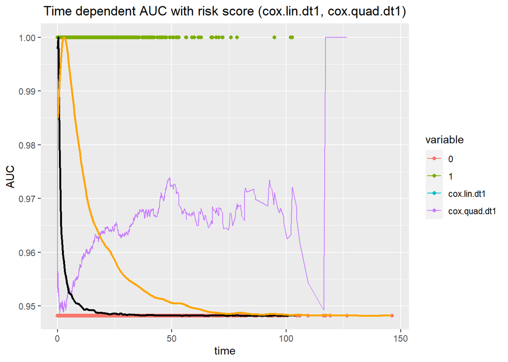

```r
dt1$censor1 <- ifelse(dt1$censor==1,
                    1,min(na.omit(ROC.risk.lin.dt1[["AUC"]])))
ggplot() +
  geom_line(data=res1, aes(x=time, y=value,
                            group=variable, color=variable)) +
  geom_point(data=dt1, aes(x=time, y=censor1, color=as.factor(censor))) +
  geom_line(data=data1_1, aes(x=time, y=density.adjusted),
            size=1, colour='black') +
  geom_line(data=data1_2, aes(x=time, y=density.adjusted),
            size=1, colour='orange') +
  scale_x_continuous(limits = c(min(dt1$time), max(dt1$time))) +
  ggtitle("Time dependent AUC with risk score (cox.lin.dt1, cox.quad.dt1)") +
  xlab("time") + ylab("AUC") +
  theme(plot.title = element_text(hjust = 0.5))
```

#### Mean value of Time dependent AUC (cox.lin.dt1, cox.quad.dt1)

```r
mean(ROC.risk.lin.dt1[["AUC"]],na.rm=TRUE)
```

```
## [1] 0.9562299
```

```r
mean(ROC.risk.quad.dt1[["AUC"]],na.rm=TRUE)
```

```
## [1] 0.9562299
```

#### Counting censored data

```r
dt1.censor <- dt1[dt1$censor==0,]
dt1.censor <- dt1.censor %>%
  mutate(n.cen=cut(dt1.censor$time,
                   breaks=seq(from=0,to=200,by=5)))
table(dt1.censor$n.cen)
```

```
##
##     (0,5]    (5,10]   (10,15]   (15,20]   (20,25]   (25,30]   (30,35]   (35,40]
##      1435       845       530       365       291       180       149       108
##   (40,45]   (45,50]   (50,55]   (55,60]   (60,65]   (65,70]   (70,75]   (75,80]
##        78        64        57        37        27        15         8         8
##   (80,85]   (85,90]   (90,95]  (95,100] (100,105] (105,110] (110,115] (115,120]
##        10         6         7         5         3         3         0         3
## (120,125] (125,130] (130,135] (135,140] (140,145] (145,150] (150,155] (155,160]
##         0         1         0         0         0         1         0         0
## (160,165] (165,170] (170,175] (175,180] (180,185] (185,190] (190,195] (195,200]
##         0         0         0         0         0         0         0         0
```

## Assume quadratic relationship

```r
# Assume parametric basis distribution is Exponential distribution...
lambda1 <- 0.1 # parameter for generate Y
lambda2 <- 0.05 # parameter for generate C
beta1 <- 3 ; beta2 <- 2 # true coefficients
Y <- c() # real survival time
C <- c() # censoring time
t <- c() # observed survival time
censor <- c() # censoring indicator
X <- c() # explanatory variable
U1 <- c() # random variable from U(0,1) for generate Y
U2 <- c() # random variable from U(0,1) for generate C
X2 <- c() # X^2

for (i in 1:10000) {
  U1[i] <- runif(1)
  U2[i] <- runif(1)
  # X[i] <- runif(1,min=0,max=10)
  X[i] <- rnorm(1,mean=0,sd=1)
  X2[i] <- X[i]^2
  Y[i] <- -(1/lambda1)*log(U1[i])*exp(-beta1*X[i]-beta2*X2[i])
  C[i] <- -(1/lambda2)*log(U2[i])
  t[i] <- min(Y[i],C[i])
  censor[i] <- ifelse(Y[i]<=C[i],1,0)
}

mean(1-censor) # censoring rate
```

```
## [1] 0.2737
```

```r
dt2 <- data.frame(X=X, X2=X2, Y=Y, C=C, time=t, censor=censor)
head(dt2,20)
```

```
##              X          X2           Y           C        time censor
## 1  -1.27038162 1.613869465 11.84811598   4.1726093  4.17260925      0
## 2   0.47359533 0.224292538  0.22401298   9.8197602  0.22401298      1
## 3   0.33381105 0.111429820  1.69214881  20.7137117  1.69214881      1
## 4   0.07557225 0.005711164 14.07904269   7.2665934  7.26659338      0
## 5   0.46691671 0.218011214  0.14559928  58.4308192  0.14559928      1
## 6  -0.72488936 0.525464586  5.90412904  12.8669966  5.90412904      1
## 7   1.23975946 1.537003528  0.00834158   9.3230097  0.00834158      1
## 8  -1.69486664 2.872572917  1.11059142 105.0938094  1.11059142      1
## 9   0.63305799 0.400762414  0.07136117  17.6851971  0.07136117      1
## 10  0.06157627 0.003791637  5.02030827  41.7486958  5.02030827      1
## 11  0.77617412 0.602446271  0.20184044   2.9401544  0.20184044      1
## 12 -1.37104623 1.879767769  0.50002365   1.0106455  0.50002365      1
## 13 -0.17372507 0.030180399 10.27326958  13.6929646 10.27326958      1
## 14 -0.38973385 0.151892470 42.57132588  13.6634765 13.66347645      0
## 15  0.24819799 0.061602240  5.20226681  16.8074906  5.20226681      1
## 16 -0.22650725 0.051305535  2.45497736  10.8526706  2.45497736      1
## 17 -0.53235436 0.283401161  8.21580723   2.4881192  2.48811923      0
## 18  0.87275896 0.761708194  0.11776553   0.4070022  0.11776553      1
## 19 -0.13294211 0.017673604 47.78525158  27.8671744 27.86717442      0
## 20 -1.00276018 1.005527986 42.04611674  39.1244047 39.12440474      0
```

```r
# dt2[c(order(dt2$time)),]$censor
```

### True model

- $h(t|x)=h _{0} (t)exp[f(x)]$
- $f(x)=\beta_{1} x + \beta_{2} x^2$
- True coefficients : $\beta_{1}=3, \beta_{2}=2$

### Set linear model

- $h(t|x)=h _{0} (t)exp[f(x)]$
- $f(x)=\beta_{1}x$

```r
cox.lin.dt2 <- coxph(Surv(time,censor) ~ X, data=dt2)
summary(cox.lin.dt2)
```

```
## Call:
## coxph(formula = Surv(time, censor) ~ X, data = dt2)
##
##   n= 10000, number of events= 7263
##
##      coef exp(coef) se(coef)     z Pr(>|z|)
## X 1.98386   7.27076  0.02606 76.13   <2e-16 ***
## ---
## Signif. codes:  0 '***' 0.001 '**' 0.01 '*' 0.05 '.' 0.1 ' ' 1
##
##   exp(coef) exp(-coef) lower .95 upper .95
## X     7.271     0.1375     6.909     7.652
##
## Concordance= 0.811  (se = 0.004 )
## Likelihood ratio test= 7781  on 1 df,   p=<2e-16
## Wald test            = 5796  on 1 df,   p=<2e-16
## Score (logrank) test = 6461  on 1 df,   p=<2e-16
```

```r
risk.lin.dt2 <- predict(object=cox.lin.dt2, newdata=dt2, type="risk") # risk score
dt2$risk.lin.dt2 <- risk.lin.dt2
ROC.risk.lin.dt2 <- timeROC(T=dt2$time,
                         delta=dt2$censor,marker=dt2$risk.lin.dt2,
                         cause=1,weighting="marginal",
                         times=dt2$time)
ROC.risk.lin.dt2
```

```
## Time-dependent-Roc curve estimated using IPCW  (n=10000, without competing risks).
##                        Cases Survivors Censored AUC (%)
## t=2.62046600187719e-15     0      9999        1      NA
## t=0.151110449439603     2437      7499       64   92.20
## t=1.96265954474797      4396      5000      604   85.57
## t=7.42372434476001      5965      2500     1535   81.38
## t=95.9304504707793      7263         0     2737      NA
##
## Method used for estimating IPCW:marginal
##
## Total computation time : 46.87  secs.
```

### Set quadratic model

- $h(t|x)=h _{0} (t)exp[f(x)]$
- $f(x)=\beta_{1}x+\beta_{2}x^2$

```r
cox.quad.dt2 <- coxph(Surv(time,censor) ~ X+X2, data=dt2)
summary(cox.quad.dt2)
```

```
## Call:
## coxph(formula = Surv(time, censor) ~ X + X2, data = dt2)
##
##   n= 10000, number of events= 7263
##
##        coef exp(coef) se(coef)     z Pr(>|z|)
## X   2.40958  11.12931  0.02550 94.50   <2e-16 ***
## X2  1.51408   4.54522  0.01862 81.31   <2e-16 ***
## ---
## Signif. codes:  0 '***' 0.001 '**' 0.01 '*' 0.05 '.' 0.1 ' ' 1
##
##    exp(coef) exp(-coef) lower .95 upper .95
## X     11.129    0.08985    10.587    11.700
## X2     4.545    0.22001     4.382     4.714
##
## Concordance= 0.874  (se = 0.002 )
## Likelihood ratio test= 15102  on 2 df,   p=<2e-16
## Wald test            = 9226  on 2 df,   p=<2e-16
## Score (logrank) test = 27622  on 2 df,   p=<2e-16
```

```r
risk.quad.dt2 <- predict(object=cox.quad.dt2, newdata=dt2, type="risk") # risk score
dt2$risk.quad.dt2 <- risk.quad.dt2
ROC.risk.quad.dt2 <- timeROC(T=dt2$time,
                         delta=dt2$censor,marker=dt2$risk.quad.dt2,
                         cause=1,weighting="marginal",
                         times=dt2$time)
ROC.risk.quad.dt2
```

```
## Time-dependent-Roc curve estimated using IPCW  (n=10000, without competing risks).
##                        Cases Survivors Censored AUC (%)
## t=2.62046600187719e-15     0      9999        1      NA
## t=0.151110449439603     2437      7499       64   97.40
## t=1.96265954474797      4396      5000      604   93.00
## t=7.42372434476001      5965      2500     1535   89.83
## t=95.9304504707793      7263         0     2737      NA
##
## Method used for estimating IPCW:marginal
##
## Total computation time : 37.16  secs.
```

#### Make AUC data

```r
# uncensored
uncensored.density2 <- density(dt2$time[dt2$censor==1])
data2_1 <- data.frame(time=uncensored.density2[["x"]],
                    density=uncensored.density2[["y"]])
data2_1$density.adjusted <- (max(na.omit(ROC.risk.lin.dt2[["AUC"]]))-min(na.omit(ROC.risk.lin.dt2[["AUC"]])))*(uncensored.density2[["y"]]-min(uncensored.density2[["y"]]))/(max(uncensored.density2[["y"]])-min(uncensored.density2[["y"]]))+min(na.omit(ROC.risk.lin.dt2[["AUC"]]))

# censored
censored.density2 <- density(dt2$time[dt2$censor==0])
data2_2 <- data.frame(time=censored.density2[["x"]],
                    density=censored.density2[["y"]])
data2_2$density.adjusted <- (max(na.omit(ROC.risk.lin.dt2[["AUC"]]))-min(na.omit(ROC.risk.lin.dt2[["AUC"]])))*(censored.density2[["y"]]-min(censored.density2[["y"]]))/(max(censored.density2[["y"]])-min(censored.density2[["y"]]))+min(na.omit(ROC.risk.lin.dt2[["AUC"]]))

res2 <- data.frame(time=ROC.risk.lin.dt2[["times"]],
                    cox.lin.dt2=ROC.risk.lin.dt2[["AUC"]],
                    cox.quad.dt2=ROC.risk.quad.dt2[["AUC"]])
res2 <- melt(data = res2,
                   id.vars = "time",
                   measure.vars = c("cox.lin.dt2","cox.quad.dt2"))
```

#### Time dependent AUC plot with ggplot2 (cox.lin.dt2, cox.quad.dt2)

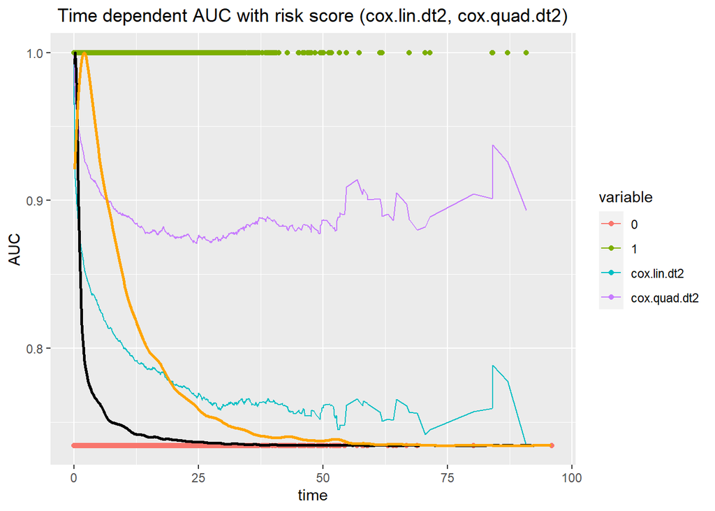

```r
dt2$censor1 <- ifelse(dt2$censor==1,
                    1,min(na.omit(ROC.risk.lin.dt2[["AUC"]])))
ggplot() +
  geom_line(data=res2, aes(x=time, y=value,
                            group=variable, color=variable)) +
  geom_point(data=dt2, aes(x=time, y=censor1, color=as.factor(censor))) +
  geom_line(data=data2_1, aes(x=time, y=density.adjusted),
            size=1, colour='black') +
  geom_line(data=data2_2, aes(x=time, y=density.adjusted),
            size=1, colour='orange') +
  scale_x_continuous(limits = c(min(dt2$time), max(dt2$time))) +
  ggtitle("Time dependent AUC with risk score (cox.lin.dt2, cox.quad.dt2)") +
  xlab("time") + ylab("AUC") +
  theme(plot.title = element_text(hjust = 0.5))
```

#### Mean value of Time dependent AUC (cox.lin.dt2, cox.quad.dt2)

```r
mean(ROC.risk.lin.dt2[["AUC"]],na.rm=TRUE)
```

```
## [1] 0.8676814
```

```r
mean(ROC.risk.quad.dt2[["AUC"]],na.rm=TRUE)
```

```
## [1] 0.93467
```

#### Counting censored data

```r
dt2.censor <- dt2[dt2$censor==0,]
dt2.censor <- dt2.censor %>%
  mutate(n.cen=cut(dt2.censor$time,
                   breaks=seq(from=0,to=200,by=5)))
table(dt2.censor$n.cen)
```

```
##
##     (0,5]    (5,10]   (10,15]   (15,20]   (20,25]   (25,30]   (30,35]   (35,40]
##      1197       629       336       218       137        80        49        26
##   (40,45]   (45,50]   (50,55]   (55,60]   (60,65]   (65,70]   (70,75]   (75,80]
##        23        14        16         5         3         2         0         0
##   (80,85]   (85,90]   (90,95]  (95,100] (100,105] (105,110] (110,115] (115,120]
##         1         0         0         1         0         0         0         0
## (120,125] (125,130] (130,135] (135,140] (140,145] (145,150] (150,155] (155,160]
##         0         0         0         0         0         0         0         0
## (160,165] (165,170] (170,175] (175,180] (180,185] (185,190] (190,195] (195,200]
##         0         0         0         0         0         0         0         0
```

## Compare two results

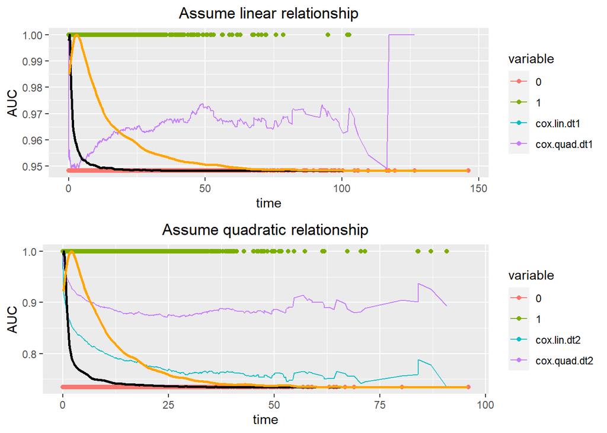

```r
a <- ggplot()

fig1 <- a +
  geom_line(data=res1, aes(x=time, y=value,
                            group=variable, color=variable)) +
  geom_point(data=dt1, aes(x=time, y=censor1, color=as.factor(censor))) +
  geom_line(data=data1_1, aes(x=time, y=density.adjusted),
            size=1, colour='black') +
  geom_line(data=data1_2, aes(x=time, y=density.adjusted),
            size=1, colour='orange') +
  scale_x_continuous(limits = c(min(dt1$time), max(dt1$time))) +
  ggtitle("Assume linear relationship") +
  xlab("time") + ylab("AUC") +
  theme(plot.title = element_text(hjust = 0.5))

fig2 <- a +
  geom_line(data=res2, aes(x=time, y=value,
                            group=variable, color=variable)) +
  geom_point(data=dt2, aes(x=time, y=censor1, color=as.factor(censor))) +
  geom_line(data=data2_1, aes(x=time, y=density.adjusted),
            size=1, colour='black') +
  geom_line(data=data2_2, aes(x=time, y=density.adjusted),
            size=1, colour='orange') +
  scale_x_continuous(limits = c(min(dt2$time), max(dt2$time))) +
  ggtitle("Assume quadratic relationship") +
  xlab("time") + ylab("AUC") +
  theme(plot.title = element_text(hjust = 0.5))

grid.arrange(fig1, fig2, nrow=2, ncol=1)
```